# Harpur Enrollment

Dave Clark

2026-09-17

## Most of the change over three Fall semesters is at the 100 level

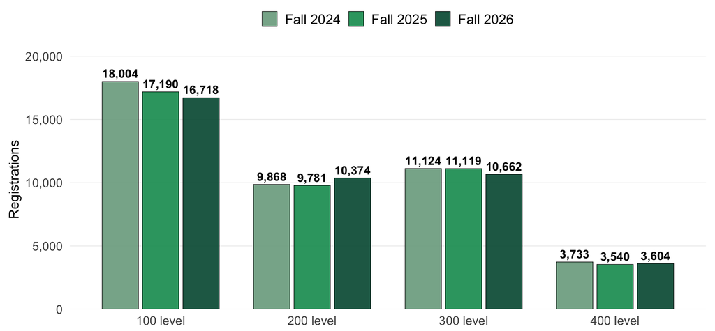

## Registrations by division

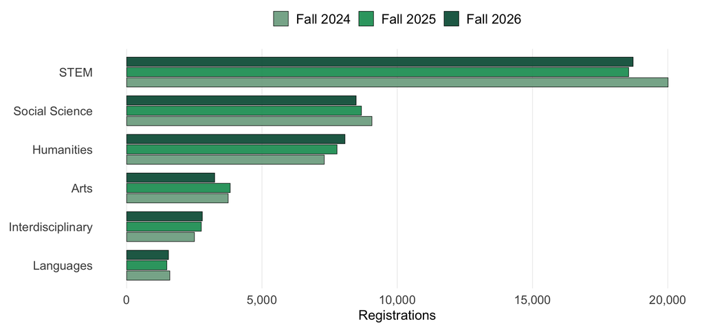

## Department change, Fall 2024 → Fall 2025

Departments with at least 50 registrations in Fall 2024 or Fall 2026.

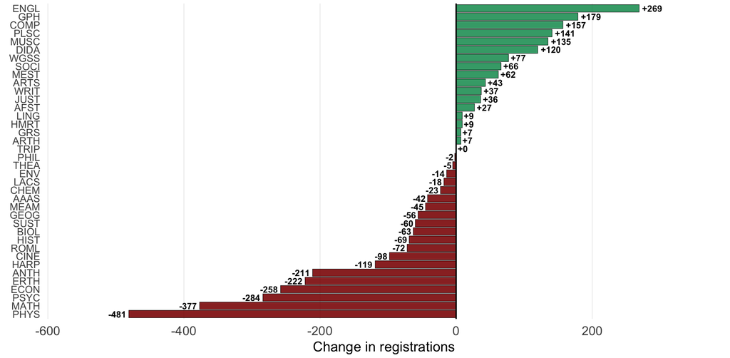

## Department change, Fall 2025 → Fall 2026

Departments with at least 50 registrations in Fall 2024 or Fall 2026.

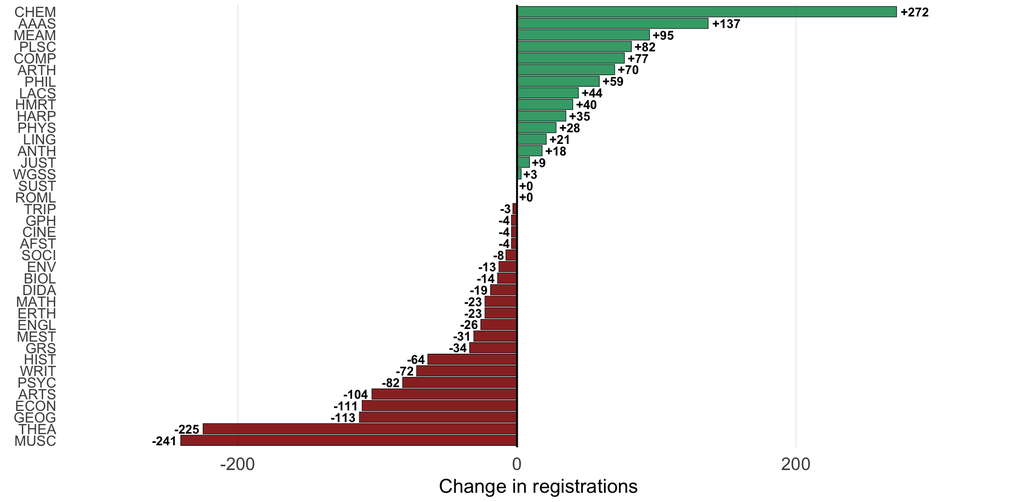

## Two different years, not one trend

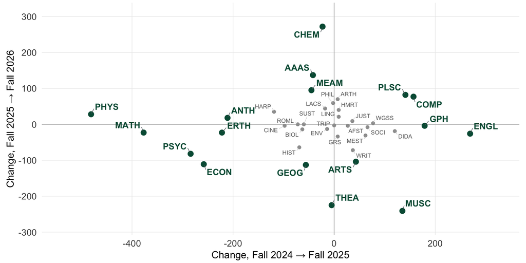

## AP credit has doubled

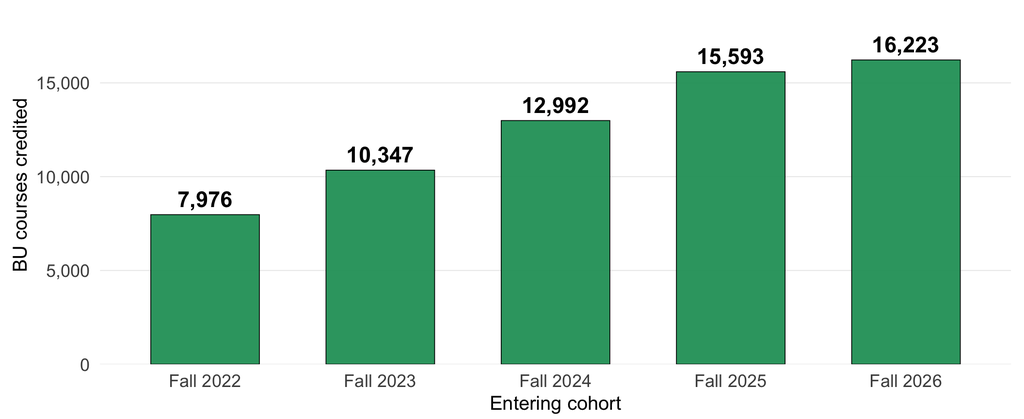

All colleges — the summary sheet’s Fall 2026 column. It counts **course credits granted**, one per student per exam per BU course. Nine in ten exams credit one course, so 16,223 credits came from 14,273 exams; the gap is calculus and biology, where one exam credits several courses (eg, a Calculus BC exam credits MATH 224, 225, 226 and an elective).

## Each student brings more of it

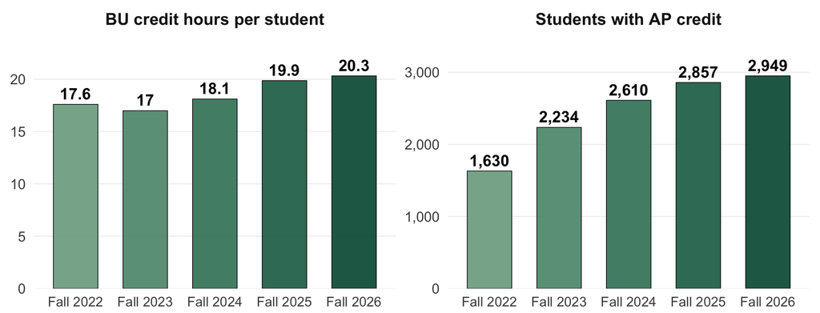

## What students are getting credit for

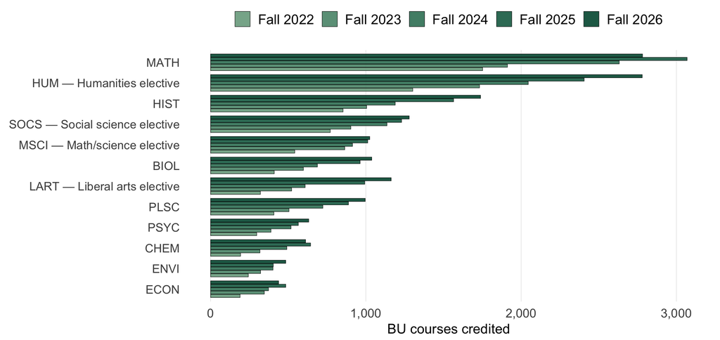

**HUM** humanities elective, **SOCS** social science elective, **MSCI** math/science elective, **LART** liberal arts elective. All four are Harpur requirements.